# Phân cụm khách hàng US Airways

Nguyen Phuong Nam

2025-05-17

# Introduction

In the increasingly competitive landscape of the airline industry, understanding customer satisfaction has become a key factor in improving service quality and retaining loyal customers. This study focuses on analyzing customer satisfaction with US Airways based on 14 factors related to the flight experience. By applying Principal Component Analysis (PCA), K-means clustering, and data visualization techniques, the research aims to identify distinct customer segments, uncover strengths and weaknesses in the current service, and propose specific and effective improvement strategies.

# Data Preprocessing

## About the Dataset

The data was obtained from the open data source website *https://www.kaggle.com/datasets/johndddddd/customer-satisfaction* by John D. It describes customer satisfaction related to their flight experience with US Airways (USA), based on a survey conducted in 2015. The dataset’s information is presented as follows:

|  | Field | Description |
| --- | --- | --- |
| 1 | ID | Unique passenger identifier |
| 2 | Gender | Gender of the passenger (Female/Male) |
| 3 | Age | Age of the passenger |
| 4 | Customer Type | Type of airline customer (First-time/Returning) |
| 5 | Type of Travel | Purpose of the flight (Business/Personal) |
| 6 | Class | Travel class in the airplane for the passenger seat |
| 7 | Flight Distance | Flight distance in miles |
| 8 | Departure Delay | Flight departure delay in minutes |
| 9 | Arrival Delay | Flight arrival delay in minutes |
| 10 | Departure and Arrival Time Convenience | Satisfaction level with the convenience of the flight departure and arrival times from 1 (lowest) to 5 (highest) - 0 means "not applicable" |

[output cut: 14 more lines]

## Data Import and Processing

### Import Raw Data

The data is directly updated from the *Kaggle* website. However, to ensure RStudio runs smoothly, the author has hosted it on *Github* as an intermediary (*Internet connection required when running*) to avoid potential errors when crawling the data.

```r
library(readr)
url <- "https://raw.githubusercontent.com/cedric4904/Airplane/refs/heads/main/airline_passenger_satisfaction.csv"
airline_data <- read_csv(url)
```

Descriptive stastistics is listed in the table below:

```r
library(skimr)
skim(airline_data)
```

Data summary

| Name | airline_data |
| --- | --- |
| Number of rows | 129880 |
| Number of columns | 24 |
| _______________________ |  |
| Column type frequency: |  |
| character | 5 |
| numeric | 19 |
| ________________________ |  |
| Group variables | None |

**Variable type: character**

| skim_variable | n_missing | complete_rate | min | max | empty | n_unique | whitespace |
| --- | --- | --- | --- | --- | --- | --- | --- |
| Gender | 0 | 1 | 4 | 6 | 0 | 2 | 0 |
| Customer Type | 0 | 1 | 9 | 10 | 0 | 2 | 0 |
| Type of Travel | 0 | 1 | 8 | 8 | 0 | 2 | 0 |
| Class | 0 | 1 | 7 | 12 | 0 | 3 | 0 |
| Satisfaction | 0 | 1 | 9 | 23 | 0 | 2 | 0 |

**Variable type: numeric**

| skim_variable | n_missing | complete_rate | mean | sd | p0 | p25 | p50 | p75 | p100 | hist |
| --- | --- | --- | --- | --- | --- | --- | --- | --- | --- | --- |
| ID | 0 | 1 | 64940.50 | 37493.27 | 1 | 32470.75 | 64940.5 | 97410.25 | 129880 | ▇▇▇▇▇ |
| Age | 0 | 1 | 39.43 | 15.12 | 7 | 27.00 | 40.0 | 51.00 | 85 | ▃▇▇▅▁ |
| Flight Distance | 0 | 1 | 1190.32 | 997.45 | 31 | 414.00 | 844.0 | 1744.00 | 4983 | ▇▃▂▁▁ |
| Departure Delay | 0 | 1 | 14.71 | 38.07 | 0 | 0.00 | 0.0 | 12.00 | 1592 | ▇▁▁▁▁ |
| Arrival Delay | 393 | 1 | 15.09 | 38.47 | 0 | 0.00 | 0.0 | 13.00 | 1584 | ▇▁▁▁▁ |
| Departure and Arrival Time Convenience | 0 | 1 | 3.06 | 1.53 | 0 | 2.00 | 3.0 | 4.00 | 5 | ▆▆▆▇▇ |
| Ease of Online Booking | 0 | 1 | 2.76 | 1.40 | 0 | 2.00 | 3.0 | 4.00 | 5 | ▇▇▇▆▅ |
| Check-in Service | 0 | 1 | 3.31 | 1.27 | 0 | 3.00 | 3.0 | 4.00 | 5 | ▃▃▇▇▆ |
| Online Boarding | 0 | 1 | 3.25 | 1.35 | 0 | 2.00 | 3.0 | 4.00 | 5 | ▃▅▆▇▆ |
| Gate Location | 0 | 1 | 2.98 | 1.28 | 0 | 2.00 | 3.0 | 4.00 | 5 | ▅▆▇▇▃ |
| On-board Service | 0 | 1 | 3.38 | 1.29 | 0 | 2.00 | 4.0 | 4.00 | 5 | ▃▃▆▇▆ |
| Seat Comfort | 0 | 1 | 3.44 | 1.32 | 0 | 2.00 | 4.0 | 5.00 | 5 | ▃▃▅▇▇ |
| Leg Room Service | 0 | 1 | 3.35 | 1.32 | 0 | 2.00 | 4.0 | 4.00 | 5 | ▃▆▆▇▇ |
| Cleanliness | 0 | 1 | 3.29 | 1.31 | 0 | 2.00 | 3.0 | 4.00 | 5 | ▃▅▇▇▇ |
| Food and Drink | 0 | 1 | 3.20 | 1.33 | 0 | 2.00 | 3.0 | 4.00 | 5 | ▅▇▇▇▇ |
| In-flight Service | 0 | 1 | 3.64 | 1.18 | 0 | 3.00 | 4.0 | 5.00 | 5 | ▂▂▅▇▆ |
| In-flight Wifi Service | 0 | 1 | 2.73 | 1.33 | 0 | 2.00 | 3.0 | 4.00 | 5 | ▆▇▇▆▃ |
| In-flight Entertainment | 0 | 1 | 3.36 | 1.33 | 0 | 2.00 | 4.0 | 4.00 | 5 | ▃▅▅▇▇ |
| Baggage Handling | 0 | 1 | 3.63 | 1.18 | 1 | 3.00 | 4.0 | 5.00 | 5 | ▂▂▅▇▆ |

### Handle Missing Values

As described above, the dataset used includes 24 variables with 129,880 corresponding observations. First, the author performed a check for missing values and found 393 observations containing missing data. As a result, these were removed from the dataset.

```r
colSums(is.na(airline_data))
```

```
##                                     ID                                 Gender
##                                      0                                      0
##                                    Age                          Customer Type
##                                      0                                      0
##                         Type of Travel                                  Class
##                                      0                                      0
##                        Flight Distance                        Departure Delay
##                                      0                                      0
##                          Arrival Delay Departure and Arrival Time Convenience
##                                    393                                      0
##                 Ease of Online Booking                       Check-in Service
##                                      0                                      0
##                        Online Boarding                          Gate Location
##                                      0                                      0
##                       On-board Service                           Seat Comfort
##                                      0                                      0
##                       Leg Room Service                            Cleanliness
##                                      0                                      0
##                         Food and Drink                      In-flight Service
##                                      0                                      0
##                 In-flight Wifi Service                In-flight Entertainment
##                                      0                                      0
##                       Baggage Handling                           Satisfaction
##                                      0                                      0
```

```r
airline_data <- na.omit(airline_data)
sum(is.na(airline_data))
```

```
## [1] 0
```

After that, the dataset no longer contained any missing values

### Handle Duplicate Values

Next, using the customer ID, the author removed duplicate entries from the dataset (observations appearing more than once were excluded).

```r
library(dplyr)
airline_data$ID <- airline_data %>% distinct(airline_data$ID)
```

### Filter Variables for Analysis

Based on the initial information from the dataset, the variables measuring customer satisfaction use a Likert scale (1–5). However, some responses are recorded as “0” – Not applicable, meaning no response was given. To ensure the accuracy and objectivity of the subsequent analyses, the author filtered out observations with values equal to 0, retaining only those greater than 0. As a result, the dataset was reduced to 119,204 observations.

```r
library(dplyr)
airline_data <- airline_data %>%
    filter(if_all(10:23, ~ .x > 0))
```

### Select 10% Sample from the Dataset

With 119,204 observations in the dataset, performing subsequent analyses would be memory-intensive and could cause the system to freeze due to the large data volume and time-consuming computations. Therefore, the author opted to use a 10% random sample without replacement. After sampling, the dataset was reduced to approximately 11,920 observations.

```r
library(dplyr)
set.seed(123)
airline_data <- sample_frac(airline_data, size = 0.1) #chon khong hoan lai
skim(airline_data)
```

Data summary

| Name | airline_data |
| --- | --- |
| Number of rows | 11920 |
| Number of columns | 24 |
| _______________________ |  |
| Column type frequency: |  |
| character | 6 |
| numeric | 18 |
| ________________________ |  |
| Group variables | None |

**Variable type: character**

| skim_variable | n_missing | complete_rate | min | max | empty | n_unique | whitespace |
| --- | --- | --- | --- | --- | --- | --- | --- |
| ID | 0 | 1 | 85343 | 85343 | 0 | 11920 | 0 |
| Gender | 0 | 1 | 4 | 6 | 0 | 2 | 0 |
| Customer Type | 0 | 1 | 9 | 10 | 0 | 2 | 0 |
| Type of Travel | 0 | 1 | 8 | 8 | 0 | 2 | 0 |
| Class | 0 | 1 | 7 | 12 | 0 | 3 | 0 |
| Satisfaction | 0 | 1 | 9 | 23 | 0 | 2 | 0 |

**Variable type: numeric**

| skim_variable | n_missing | complete_rate | mean | sd | p0 | p25 | p50 | p75 | p100 | hist |
| --- | --- | --- | --- | --- | --- | --- | --- | --- | --- | --- |
| Age | 0 | 1 | 39.80 | 15.03 | 7 | 28 | 40 | 51 | 85 | ▃▇▇▅▁ |
| Flight Distance | 0 | 1 | 1214.72 | 996.53 | 31 | 438 | 862 | 1768 | 4983 | ▇▃▂▁▁ |
| Departure Delay | 0 | 1 | 14.98 | 39.37 | 0 | 0 | 0 | 13 | 1592 | ▇▁▁▁▁ |
| Arrival Delay | 0 | 1 | 15.53 | 40.13 | 0 | 0 | 0 | 14 | 1584 | ▇▁▁▁▁ |
| Departure and Arrival Time Convenience | 0 | 1 | 3.22 | 1.39 | 1 | 2 | 3 | 4 | 5 | ▅▆▆▇▇ |
| Ease of Online Booking | 0 | 1 | 2.87 | 1.30 | 1 | 2 | 3 | 4 | 5 | ▆▇▇▆▅ |
| Check-in Service | 0 | 1 | 3.29 | 1.27 | 1 | 2 | 3 | 4 | 5 | ▃▃▇▇▆ |
| Online Boarding | 0 | 1 | 3.31 | 1.27 | 1 | 2 | 4 | 4 | 5 | ▃▅▆▇▆ |
| Gate Location | 0 | 1 | 2.98 | 1.28 | 1 | 2 | 3 | 4 | 5 | ▅▆▇▇▅ |
| On-board Service | 0 | 1 | 3.38 | 1.29 | 1 | 2 | 4 | 4 | 5 | ▃▃▆▇▆ |
| Seat Comfort | 0 | 1 | 3.44 | 1.31 | 1 | 2 | 4 | 4 | 5 | ▃▃▅▇▆ |
| Leg Room Service | 0 | 1 | 3.37 | 1.30 | 1 | 2 | 4 | 4 | 5 | ▃▆▆▇▇ |
| Cleanliness | 0 | 1 | 3.27 | 1.31 | 1 | 2 | 3 | 4 | 5 | ▃▅▇▇▆ |
| Food and Drink | 0 | 1 | 3.19 | 1.32 | 1 | 2 | 3 | 4 | 5 | ▅▇▇▇▇ |
| In-flight Service | 0 | 1 | 3.64 | 1.17 | 1 | 3 | 4 | 5 | 5 | ▂▂▅▇▆ |
| In-flight Wifi Service | 0 | 1 | 2.80 | 1.25 | 1 | 2 | 3 | 4 | 5 | ▆▇▇▆▃ |
| In-flight Entertainment | 0 | 1 | 3.35 | 1.33 | 1 | 2 | 4 | 4 | 5 | ▃▅▅▇▆ |
| Baggage Handling | 0 | 1 | 3.64 | 1.17 | 1 | 3 | 4 | 5 | 5 | ▂▂▅▇▆ |

# Dimensionality Reduction with PCA

## Prepare Input Data for PCA

Principal Component Analysis (PCA) is one of the multivariate data analysis techniques used in statistics to reduce data dimensionality. The aim of this method is to “condense” the data while minimizing information loss. It is applicable to quantitative variables or ordinal variables (such as those measured on a ranked scale).

Given that the dataset uses a Likert scale from 1 to 5 (from “Very Dissatisfied” to “Very Satisfied”), applying PCA is entirely appropriate. The dataset includes 14 survey questions related to various aspects of customer satisfaction with the flight experience on US Airways. If K-means clustering (discussed later) were applied directly, the results could be significantly affected due to potential overlap or redundancy among these questions. Therefore, the author conducted PCA to reduce dimensionality and identify underlying latent factors before proceeding with more in-depth analysis.

The filtered dataset, containing only the Likert-scale variables, is named “data”.

```r
library(dplyr)
data <- airline_data %>% select(10:23)
head(data)
```

```
## # A tibble: 6 × 14
##   Departure and Arrival Time Conveni…¹ Ease of Online Booki…² `Check-in Service`
##                                  <dbl>                  <dbl>              <dbl>
## 1                                    1                      3                  3
## 2                                    2                      2                  4
## 3                                    2                      2                  3
## 4                                    1                      1                  4
## 5                                    5                      5                  5
## 6                                    2                      1                  3
## # ℹ abbreviated names: ¹`Departure and Arrival Time Convenience`,
## #   ²`Ease of Online Booking`
## # ℹ 11 more variables: `Online Boarding` <dbl>, `Gate Location` <dbl>,
## #   `On-board Service` <dbl>, `Seat Comfort` <dbl>, `Leg Room Service` <dbl>,
## #   Cleanliness <dbl>, `Food and Drink` <dbl>, `In-flight Service` <dbl>,
## #   `In-flight Wifi Service` <dbl>, `In-flight Entertainment` <dbl>,
## #   `Baggage Handling` <dbl>
```

## Check Data Suitability for Analysis

### Correlation Coefficient

To apply PCA, the variables must be correlated with each other. If the correlation coefficients between variables are low, PCA is not appropriate. Therefore, before performing PCA, it is necessary to preliminarily assess the correlations among the variables. The results are presented in the following chart:

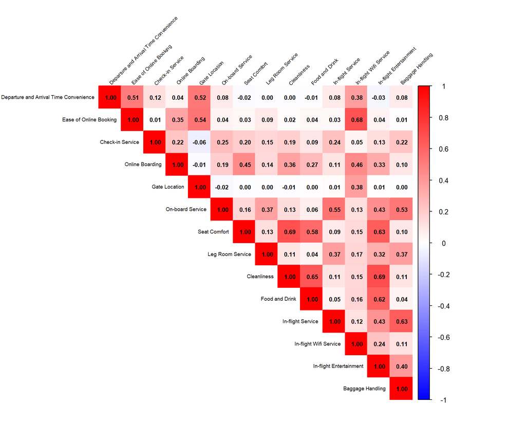

```r
library(corrplot)

# Tính ma trận tương quan
cor_mat <- cor(data, use = "complete.obs")

# Vẽ heatmap
corrplot(cor_mat, method = "color", type = "upper",
         tl.col = "black", tl.srt = 45,tl.cex = 0.6, addCoef.col = "black", number.cex = 0.7,
         col = colorRampPalette(c("blue", "white", "red"))(200))
```

### Bartlett’s Test and KMO Measure

However, when the sample size is large, as in the dataset being analyzed, correlation coefficients tend to decrease. Moreover, in PCA, besides checking the correlation coefficients among variables, it is also necessary to assess the correlation between variables and latent factors (principal components). Therefore, the author uses Bartlett’s test and the KMO (Kaiser-Meyer-Olkin) measure with the following criteria:

- The KMO coefficient must be at least 0.5 (0.5 ≤ KMO ≤ 1), indicating that exploratory factor analysis is appropriate for the dataset (Hill, 2011).
- Bartlett’s test should be statistically significant (Sig. value < 0.05), meaning that the observed variables have linear correlations with the underlying factors.

– Bartlett’s Test

```r
library(psych)
cortest.bartlett(data)
```

```
## $chisq
## [1] 72533.38
##
## $p.value
## [1] 0
##
## $df
## [1] 91
```

– KMO coefficent

```r
KMO(data)
```

```
## Kaiser-Meyer-Olkin factor adequacy
## Call: KMO(r = data)
## Overall MSA =  0.78
## MSA for each item =
## Departure and Arrival Time Convenience                 Ease of Online Booking
##                                   0.73                                   0.71
##                       Check-in Service                        Online Boarding
##                                   0.70                                   0.73
##                          Gate Location                       On-board Service
##                                   0.72                                   0.83
##                           Seat Comfort                       Leg Room Service
##                                   0.83                                   0.89
##                            Cleanliness                         Food and Drink
##                                   0.82                                   0.85
##                      In-flight Service                 In-flight Wifi Service
##                                   0.79                                   0.76
##                In-flight Entertainment                       Baggage Handling
##                                   0.77                                   0.82
```

## Perform PCA

### Select Number of Principal Components to Retain

The criteria for selecting the number of principal components (PCs) are as follows:

- Eigenvalues must be greater than the average value; for data input as a correlation matrix, eigenvalues should be greater than 1. Here, since the PCA function automatically uses the correlation matrix, eigenvalues greater than 1 are retained.
- Elbow method: The number of principal components is determined at the point after which the remaining eigenvalues are approximately equal and relatively small (Jolliffe, 2002; Peres-Neto et al., 2005).
- The cumulative percentage of variance explained by the selected principal components should be greater than 50%.

The PCA results are presented as follows:

```r
library(FactoMineR)
library(factoextra)
res.pca <- PCA(data, graph = FALSE)
summary(res.pca)
```

```
##
## Call:
## PCA(X = data, graph = FALSE)
##
##
## Eigenvalues
##                        Dim.1   Dim.2   Dim.3   Dim.4   Dim.5   Dim.6   Dim.7
## Variance               3.914   2.465   2.128   1.036   0.947   0.690   0.505
## % of var.             27.955  17.608  15.202   7.397   6.762   4.926   3.605
## Cumulative % of var.  27.955  45.563  60.765  68.162  74.924  79.850  83.455
##                        Dim.8   Dim.9  Dim.10  Dim.11  Dim.12  Dim.13  Dim.14
## Variance               0.465   0.428   0.366   0.325   0.286   0.267   0.179
## % of var.              3.318   3.058   2.617   2.325   2.042   1.907   1.278
## Cumulative % of var.  86.773  89.831  92.448  94.773  96.815  98.722 100.000
##
## Individuals (the 10 first)
##                                            Dist    Dim.1    ctr   cos2    Dim.2
## 1                                      |  3.489 | -0.830  0.001  0.057 | -0.637
## 2                                      |  2.730 |  0.780  0.001  0.082 | -1.472
## 3                                      |  2.222 |  0.636  0.001  0.082 | -1.607
## 4                                      |  3.723 |  0.381  0.000  0.010 | -1.837
## 5                                      |  4.292 |  2.902  0.018  0.457 |  1.276
## 6                                      |  3.837 | -1.346  0.004  0.123 | -1.584
## 7                                      |  3.721 |  3.119  0.021  0.703 |  0.608
## 8                                      |  3.427 | -0.976  0.002  0.081 | -0.790
## 9                                      |  4.534 | -3.032  0.020  0.447 |  1.559
## 10                                     |  5.974 | -3.059  0.020  0.262 |  2.567
##                                           ctr   cos2    Dim.3    ctr   cos2
## 1                                       0.001  0.033 | -2.352  0.022  0.454 |
## 2                                       0.007  0.291 |  0.477  0.001  0.031 |
## 3                                       0.009  0.523 |  0.230  0.000  0.011 |
## 4                                       0.011  0.243 |  0.756  0.002  0.041 |
## 5                                       0.006  0.088 | -0.593  0.001  0.019 |
## 6                                       0.009  0.170 | -2.702  0.029  0.496 |
## 7                                       0.001  0.027 | -0.047  0.000  0.000 |
## 8                                       0.002  0.053 |  2.682  0.028  0.612 |
## 9                                       0.008  0.118 | -1.302  0.007  0.082 |
## 10                                      0.022  0.185 | -3.107  0.038  0.270 |
##
## Variables (the 10 first)
##                                           Dim.1    ctr   cos2    Dim.2    ctr
## Departure and Arrival Time Convenience |  0.192  0.944  0.037 |  0.716 20.779
## Ease of Online Booking                 |  0.300  2.293  0.090 |  0.833 28.117
## Check-in Service                       |  0.359  3.300  0.129 | -0.078  0.248
## Online Boarding                        |  0.578  8.544  0.334 |  0.149  0.897
## Gate Location                          |  0.138  0.485  0.019 |  0.734 21.869
## On-board Service                       |  0.554  7.846  0.307 | -0.106  0.454
## Seat Comfort                           |  0.689 12.128  0.475 | -0.227  2.097
## Leg Room Service                       |  0.442  4.995  0.195 | -0.049  0.098
## Cleanliness                            |  0.698 12.452  0.487 | -0.245  2.439
## Food and Drink                         |  0.600  9.193  0.360 | -0.206  1.729
##                                          cos2    Dim.3    ctr   cos2
## Departure and Arrival Time Convenience  0.512 |  0.076  0.270  0.006 |
## Ease of Online Booking                  0.693 | -0.072  0.243  0.005 |
## Check-in Service                        0.006 |  0.194  1.777  0.038 |
## Online Boarding                         0.022 | -0.237  2.632  0.056 |
## Gate Location                           0.539 | -0.037  0.064  0.001 |
## On-board Service                        0.011 |  0.556 14.506  0.309 |
## Seat Comfort                            0.052 | -0.458  9.863  0.210 |
## Leg Room Service                        0.002 |  0.433  8.793  0.187 |
## Cleanliness                             0.060 | -0.472 10.483  0.223 |
## Food and Drink                          0.043 | -0.521 12.764  0.272 |
```

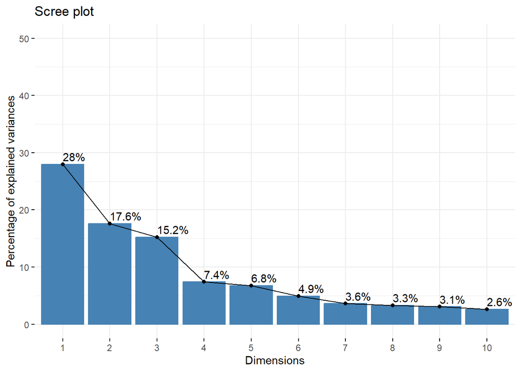

```r
fviz_eig(res.pca, addlabels = TRUE, ylim = c(0, 50))
```

### Group Original Variables into Principal Components

As mentioned above, the author decided to retain 3 principal components. To classify the original 14 variables into these principal components, the author used the **contribute** values extracted from the variables section. The contribution (CTR) indicates the extent to which a variable contributes to a principal component. To evaluate whether a variable contributes more or less to a specific component, the CTR values across the 3 principal components are compared. The highest CTR value means that the variable contributes most significantly to that component, providing a basis to assign the variable to the corresponding principal component. The results are presented as follows:

```r
#Lấy giá trị contribute
var <- get_pca_var(res.pca)
var$contrib[,1:3]
```

```
##                                             Dim.1       Dim.2       Dim.3
## Departure and Arrival Time Convenience  0.9439587 20.77880805  0.27004166
## Ease of Online Booking                  2.2929977 28.11742996  0.24306917
## Check-in Service                        3.3000053  0.24839053  1.77696802
## Online Boarding                         8.5440852  0.89654510  2.63222129
## Gate Location                           0.4846941 21.86912796  0.06408534
## On-board Service                        7.8458781  0.45440500 14.50642253
## Seat Comfort                           12.1281990  2.09708220  9.86312636
## Leg Room Service                        4.9951463  0.09833217  8.79258350
## Cleanliness                            12.4522228  2.43874739 10.48314977
## Food and Drink                          9.1928102  1.72854772 12.76409574
## In-flight Service                       7.2122714  0.39882390 19.06003068
## In-flight Wifi Service                  5.7268091 17.69031804  0.34181800
## In-flight Entertainment                18.0669437  2.66883564  0.49124041
## Baggage Handling                        6.8139784  0.51460634 18.71114753
```

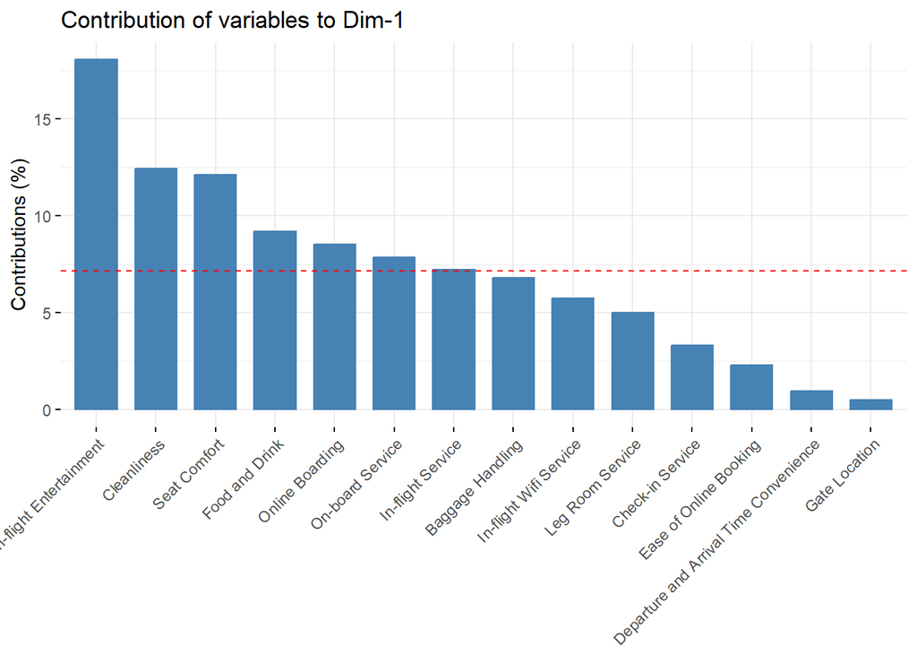

```r
fviz_contrib(res.pca, choice = "var", axes = 1)
```

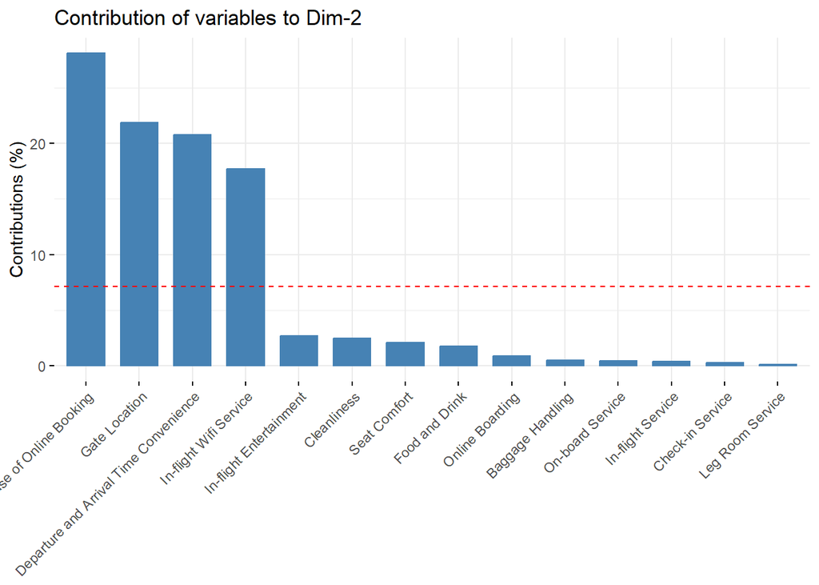

```r
fviz_contrib(res.pca, choice = "var", axes = 2)
```

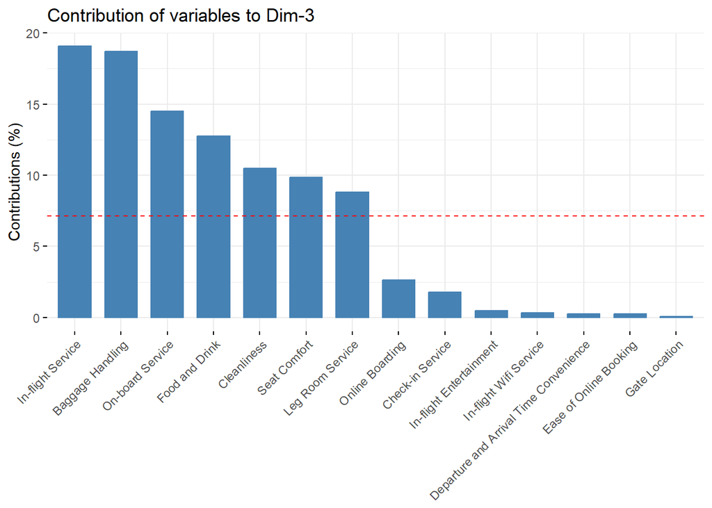

```r
fviz_contrib(res.pca, choice = "var", axes = 3)
```

Based on the obtained results, the author separated and named the 3 principal components (PCs) as follows:

– Dim.1 – “Comfort & Boarding Experience” (Sự thoải mái và tiện lợi khi bay), including variables:

- Check-in Service
- Online Boarding
- Seat Comfort
- Cleanliness
- In-flight Entertainment

– Dim.2 – “Logistics & Booking Convenience” (Thuận tiện Hành trình & Đặt vé), including variables:

- Departure and Arrival Time
- Ease of Online Booking
- Gate Location
- In-flight Wifi Service

– Dim.3 – “In-flight Service & Amenities” (Chất lượng dịch vụ chuyến bay), including variables:

- On-board Service
- Leg Room Service
- Food and Drink
- In-flight Service
- Baggage Handling

### Transforming the original data into the new principal component space

With the original data being ordinal, there are two methods to transform the data into the new principal component space (*NEU Data Analysis, 2022*). The author chose the method of calculating the principal components by multiplying the eigenvector by the centered or standardized transposed data. According to this method, the new values are standardized scores with a mean of zero; in other words, the data is normalized.

To facilitate the subsequent K-means clustering analysis (which requires normalized input data), the author will use this calculation approach. The multiplication results have been precomputed by the PCA function and are presented in the **UIndividual** section. The transformed values of the first 6 observations are as follows:

```r
res.ind <- get_pca_ind(res.pca)  # lấy thông tin mục individual
pc_scores_3d <- as.data.frame(res.ind$coord[, 1:3])  # chỉ lấy 3 thành phần đầu
head(pc_scores_3d)
```

```
##        Dim.1      Dim.2      Dim.3
## 1 -0.8297907 -0.6368157 -2.3520158
## 2  0.7801185 -1.4724390  0.4769726
## 3  0.6357194 -1.6072726  0.2301951
## 4  0.3811124 -1.8365296  0.7563767
## 5  2.9017667  1.2758331 -0.5929719
## 6 -1.3457335 -1.5841155 -2.7018418
```

After extracted to 3 new dimensions, it would be saved to new dataset with the name **pc_scores_3d**.

# Customer Clustering Using K-means

Proposed by J. MacQueen in *Some Methods for Classification and Analysis of Multivariate Observations* (1967), cluster analysis refers to a group of multivariate techniques aimed at dividing a population (or sample) into groups (clusters) such that the objects within the same group are relatively homogeneous based on selected characteristics. Each cluster exhibits high internal similarity and significant differences compared to other clusters.

In this study, the author aims to segment customer groups in order to propose measures to improve the service and flight quality of US Airways, thereby enhancing business performance. However, since the number of variables used for analysis is 14, this could significantly affect clustering results. Therefore, the author performed dimensionality reduction earlier by grouping similar questions together, and then clusters customers based on their satisfaction levels with these grouped experiences.

Thus, in this section, the author uses the 3 principal components extracted earlier to cluster more than 11,000 original customers based on similarity. The clustering method employed is K-means, a partitioning clustering technique suitable for quantitative data or ordinal data with ranked scales.

## Check Data Suitability

To determine whether the data is suitable for cluster analysis, the author used the Hopkins statistic. The criterion is that the value should be greater than 0.5. The Hopkins index evaluates the cluster tendency of the data, and distance matrices are also plotted. The Hopkins statistic ranges between [-1, 1], with values closer to 1 indicating a stronger tendency for the dataset to form clusters.

However, because the dataset is quite large (~12,000 observations), the Hopkins test can be less effective or sensitive with such a big sample. Therefore, the author took a random sample of about 1,000 observations to perform the test.

```r
library(hopkins)
library (cluster)
library (factoextra)
library (fpc)

# Lấy ngẫu nhiên 1000 dòng để tính Hopkins
set.seed(42)
sample_indices <- sample(1:nrow(pc_scores_3d), 1000)
subset_data <- pc_scores_3d[sample_indices, ]

library(hopkins)
hopkins(subset_data)
```

```
## [1] 0.9371294
```

The Hopkins statistic is close to 1, indicating that the data is suitable for K-means clustering analysis.

## Select Optimal Number of Clusters

For the partitioning clustering method, to select an appropriate number of clusters, the author combines the following three methods:

- Visual inspection of the distances between clusters
- Silhouette plot
- Elbow method (Scree plot)

The author does not use the Gap statistic method because the large dataset requires substantial memory for its calculation, making it difficult to perform. The results are presented as follows:

– Visualization

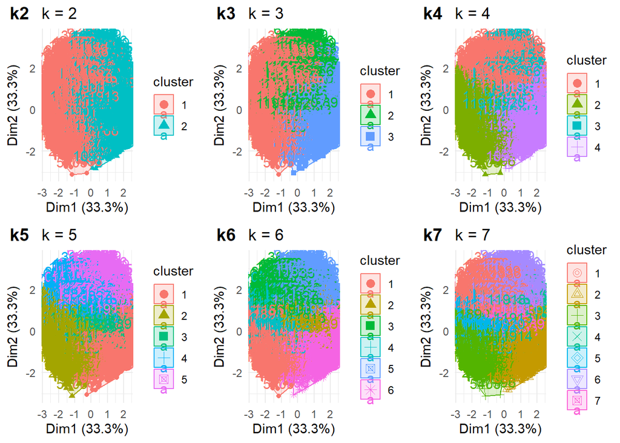

```r
kmean_calc <- function(df, k){
  kmeans(df, centers = k, nstart = 30)
}
km2 <- kmean_calc(pc_scores_3d, 2)
km3 <- kmean_calc(pc_scores_3d, 3)
km4 <- kmean_calc(pc_scores_3d, 4)
km5 <- kmean_calc(pc_scores_3d, 5)
km6 <- kmean_calc(pc_scores_3d, 6)
km7 <- kmean_calc(pc_scores_3d, 7)

p1 <- fviz_cluster(km2, data = pc_scores_3d, ellipse.type = "convex") + theme_minimal() + ggtitle("k = 2")
p2 <- fviz_cluster(km3, data = pc_scores_3d, ellipse.type = "convex") + theme_minimal() + ggtitle("k = 3")
p3 <- fviz_cluster(km4, data = pc_scores_3d, ellipse.type= "convex") + theme_minimal() + ggtitle("k = 4")
p4 <- fviz_cluster(km5, data = pc_scores_3d, ellipse.type = "convex") + theme_minimal() + ggtitle("k = 5")
p5 <- fviz_cluster(km6, data = pc_scores_3d, ellipse.type = "convex") + theme_minimal() + ggtitle("k = 6")
p6 <- fviz_cluster(km7, data = pc_scores_3d, ellipse.type = "convex") + theme_minimal() + ggtitle("k = 7")

library(cowplot)

library(ggplot2)


plot_grid(p1, p2, p3, p4, p5, p6, labels = c("k2", "k3", "k4", "k5", "k6", "k7"))
```

– Elbow and Silhouette

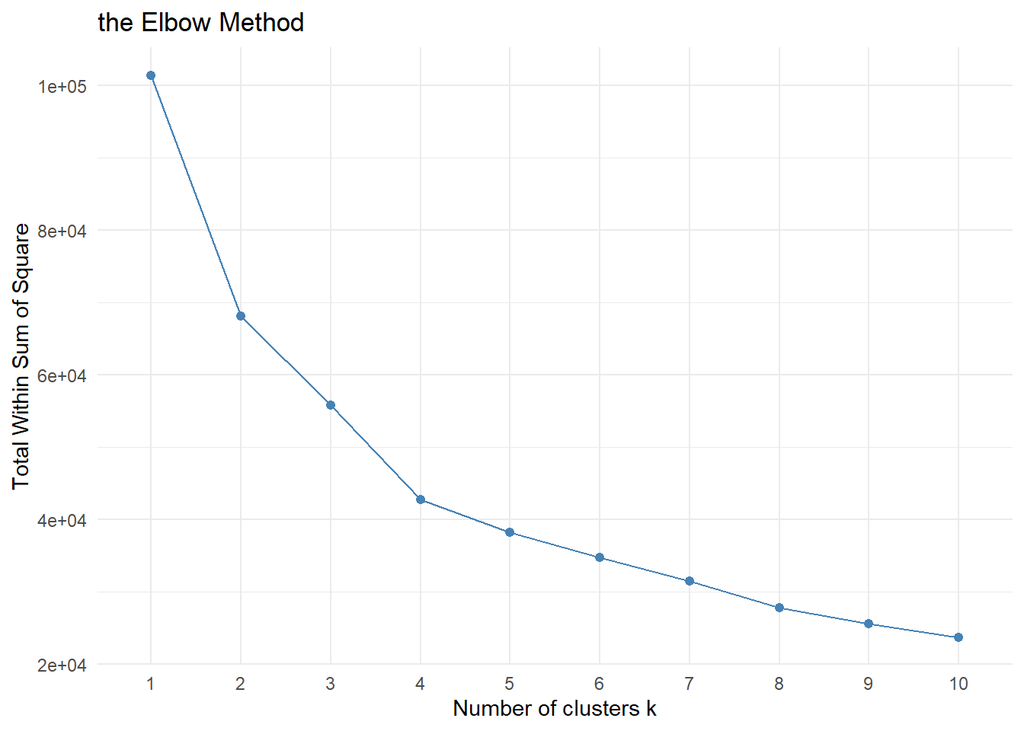

```r
# vẽ đồ thị xác định số cụm
## Dựa vào Elbow
fviz_nbclust(pc_scores_3d, kmeans, method = "wss", k.max = 10) + theme_minimal() + ggtitle("the Elbow Method")
```

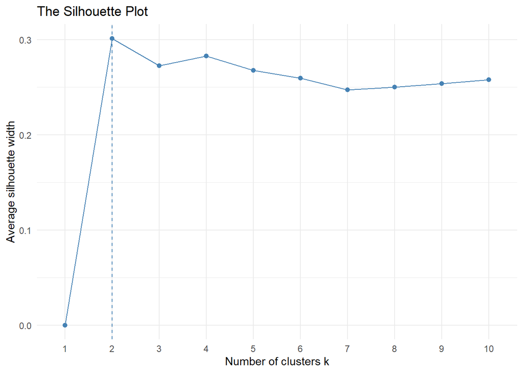

```r
### pp Silhouette
fviz_nbclust(pc_scores_3d, kmeans, method = "silhouette", k.max = 10) + theme_minimal() + ggtitle("The Silhouette Plot")
```

However, since the author aims to segment into 3 clusters corresponding to the 3 extracted principal components, the subsequent analysis will compare k = 2 and k = 3.

The best cluster number will be selected based on the following criteria:

- Average Silhouette coefficient — the closer to 1, the better
- Dunn index — the higher, the better
- BSS/TSS ratio — the proportion of between-group variance to total variance; a higher ratio indicates more distinct clusters, meaning better clustering quality

The results are presented as follows:

```r
kmean3<- kmeans (pc_scores_3d, centers=3, nstart=10)# 3 cụm(nstart represents the number of random data sets used to run the algorithm)
str(kmean3)
```

```
## List of 9
##  $ cluster     : Named int [1:11920] 3 2 2 2 1 3 1 3 3 3 ...
##   ..- attr(*, "names")= chr [1:11920] "1" "2" "3" "4" ...
##  $ centers     : num [1:3, 1:3] 1.631 0.962 -2.086 1.417 -1.474 ...
##   ..- attr(*, "dimnames")=List of 2
##   .. ..$ : chr [1:3] "1" "2" "3"
##   .. ..$ : chr [1:3] "Dim.1" "Dim.2" "Dim.3"
##  $ totss       : num 101404
##  $ withinss    : num [1:3] 13465 15221 24445
##  $ tot.withinss: num 53130
##  $ betweenss   : num 48274
##  $ size        : int [1:3] 3344 4080 4496
##  $ iter        : int 3
##  $ ifault      : int 0
##  - attr(*, "class")= chr "kmeans"
```

```r
summary(kmean3)
```

```
##              Length Class  Mode
## cluster      11920  -none- numeric
## centers          9  -none- numeric
## totss            1  -none- numeric
## withinss         3  -none- numeric
## tot.withinss     1  -none- numeric
## betweenss        1  -none- numeric
## size             3  -none- numeric
## iter             1  -none- numeric
## ifault           1  -none- numeric
```

```r
# Hiển thị thông tin tổng quan:
cat("Within-cluster sum of squares:\n")
```

```
## Within-cluster sum of squares:
```

```r
print(kmean3$withinss)
```

```
## [1] 13464.51 15221.21 24444.55
```

```r
cat("\nCluster centers:\n")
```

```
##
## Cluster centers:
```

```r
print(kmean3$centers)
```

```
##        Dim.1      Dim.2       Dim.3
## 1  1.6306282  1.4172155 -0.09787077
## 2  0.9622324 -1.4741808 -0.04310067
## 3 -2.0860162  0.2836941  0.11190627
```

```r
cat("\nSize of each cluster:\n")
```

```
##
## Size of each cluster:
```

```r
print(kmean3$size)
```

```
## [1] 3344 4080 4496
```

```r
k_stats3 <- cluster.stats(dist(pc_scores_3d), kmean3$cluster)
k_stats3
```

```
## $n
## [1] 11920
##
## $cluster.number
## [1] 3
##
## $cluster.size
## [1] 3344 4080 4496
##
## $min.cluster.size
## [1] 3344
##
## $noisen
## [1] 0
##
## $diameter
## [1] 8.408747 8.464516 9.065417
##
## $average.distance
## [1] 2.613533 2.523541 3.042939
##
## $median.distance
## [1] 2.521976 2.448541 2.951355
##
## $separation
## [1] 0.03280611 0.03280611 0.05035531
##
## $average.toother
## [1] 4.313890 4.184731 4.566012
##
## $separation.matrix
##            [,1]       [,2]       [,3]
## [1,] 0.00000000 0.03280611 0.05035531
## [2,] 0.03280611 0.00000000 0.05504161
## [3,] 0.05035531 0.05504161 0.00000000
##
## $ave.between.matrix
##          [,1]     [,2]     [,3]
## [1,] 0.000000 3.854081 4.731155
## [2,] 3.854081 0.000000 4.430660
```

[output cut: 53 more lines]

```
##
## $cwidegap
## [1] 0.9607297 0.9586854 0.9853049
##
## $widestgap
## [1] 0.9853049
##
## $sindex
## [1] 0.2276359
##
## $corrected.rand
## NULL
##
## $vi
## NULL
```

```r
kmean2<- kmeans (pc_scores_3d, centers=2, nstart=10)# 2 cụm(nstart represents the number of random data sets used to run the algorithm)
str(kmean2)
```

```
## List of 9
##  $ cluster     : Named int [1:11920] 1 2 2 2 2 1 2 1 1 1 ...
##   ..- attr(*, "names")= chr [1:11920] "1" "2" "3" "4" ...
##  $ centers     : num [1:2, 1:3] -1.8901 1.4507 0.2324 -0.1784 0.0948 ...
##   ..- attr(*, "dimnames")=List of 2
##   .. ..$ : chr [1:2] "1" "2"
##   .. ..$ : chr [1:3] "Dim.1" "Dim.2" "Dim.3"
##  $ totss       : num 101404
##  $ withinss    : num [1:2] 30480 37664
##  $ tot.withinss: num 68144
##  $ betweenss   : num 33261
##  $ size        : int [1:2] 5176 6744
##  $ iter        : int 1
##  $ ifault      : int 0
##  - attr(*, "class")= chr "kmeans"
```

```r
summary(kmean2)
```

```
##              Length Class  Mode
## cluster      11920  -none- numeric
## centers          6  -none- numeric
## totss            1  -none- numeric
## withinss         2  -none- numeric
## tot.withinss     1  -none- numeric
## betweenss        1  -none- numeric
## size             2  -none- numeric
## iter             1  -none- numeric
## ifault           1  -none- numeric
```

```r
# Hiển thị thông tin tổng quan:
cat("Within-cluster sum of squares:\n")
```

```
## Within-cluster sum of squares:
```

```r
print(kmean2$withinss)
```

```
## [1] 30480.01 37663.95
```

```r
cat("\nCluster centers:\n")
```

```
##
## Cluster centers:
```

```r
print(kmean2$centers)
```

```
##       Dim.1      Dim.2       Dim.3
## 1 -1.890133  0.2323996  0.09481776
## 2  1.450671 -0.1783660 -0.07277235
```

```r
cat("\nSize of each cluster:\n")
```

```
##
## Size of each cluster:
```

```r
print(kmean2$size)
```

```
## [1] 5176 6744
```

```r
k_stats2 <- cluster.stats(dist(pc_scores_3d), kmean2$cluster)
k_stats2
```

```
## $n
## [1] 11920
##
## $cluster.number
## [1] 2
##
## $cluster.size
## [1] 5176 6744
##
## $min.cluster.size
## [1] 5176
##
## $noisen
## [1] 0
##
## $diameter
## [1] 9.776672 9.656285
##
## $average.distance
## [1] 3.173512 3.071331
##
## $median.distance
## [1] 3.090978 2.967886
##
## $separation
## [1] 0.03538408 0.03538408
##
## $average.toother
## [1] 4.555187 4.555187
##
## $separation.matrix
##            [,1]       [,2]
## [1,] 0.00000000 0.03538408
## [2,] 0.03538408 0.00000000
##
## $ave.between.matrix
##          [,1]     [,2]
## [1,] 0.000000 4.555187
## [2,] 4.555187 0.000000
##
```

[output cut: 51 more lines]

```
##
## $cwidegap
## [1] 0.9801452 0.7398410
##
## $widestgap
## [1] 0.9801452
##
## $sindex
## [1] 0.2981788
##
## $corrected.rand
## NULL
##
## $vi
## NULL
```

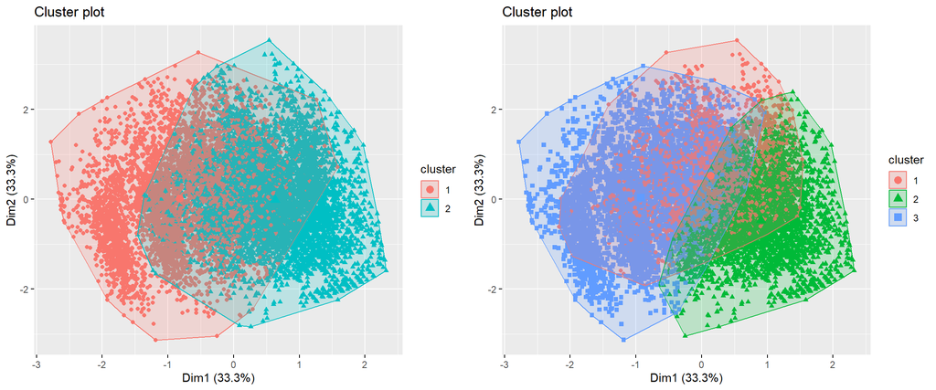

```r
plotk2 <- fviz_cluster(kmean2, data = pc_scores_3d, geom = "point", eclipse.type = "convex", repel = TRUE)
plotk3 <- fviz_cluster(kmean3, data = pc_scores_3d, geom = "point", eclipse.type = "convex", repel = TRUE)

#
library(gridExtra)
grid.arrange(plotk2, plotk3, ncol = 2)
```

– Final choice of k

*Note: The better optimal values are marked with* *

– Cluster naming

Based on the Cluster means values, which are the coordinates of the cluster centers, as follows:

Cluster means:

Cluster means:

```
  Dim.1      Dim.2       Dim.3          Cluster
```

1 *-1.890133* 0.2323996 0.09481776 1

2 1.450671 *-0.1783660* **-0.07277235** 2

**For Cluster 1 (Cluster 1)**

- Dim.1 = -1.89: very low. Thus, customers in this cluster rate poorly on **Comfort and Convenience of Flying**, including:

Check-in Service

Online Boarding

Seat Comfort

Cleanliness

In-flight Entertainment

- Dim 2 = 0.2323996 and Dim 3 = 0.09481776: opposite to Dim 1, so customers in this cluster have moderate to mild satisfaction with **Journey Convenience & Booking** and **In-flight Service Quality**

*=> Cluster Name: Cabin discomfort*: This is the group of customers who are clearly dissatisfied with comfort and convenience when boarding the plane, although they still accept the booking and in-flight service aspects.

**For Cluster 2, the results are generally opposite, specifically:**

– Assign cluster labels to the original dataset

```r
# Thêm nhãn cụm vào dữ liệu PCA
pc_scores_3d$Cluster <- kmean2$cluster
# Gắn nhãn cụm vào dữ liệu ban đầu (airline_data)
airline_data$Cluster <- pc_scores_3d$Cluster
# Kiểm tra sự phân bố của biến "Satisfaction" theo cụm
table(airline_data$Cluster, airline_data$Satisfaction)
```

```
##
##     Neutral or Dissatisfied Satisfied
##   1                    4537       639
##   2                    2386      4358
```

```r
# Kiểm tra mô tả các biến khác theo cụm
summary(airline_data[airline_data$Cluster == 1, ])  # Dữ liệu của cụm 1
```

```
##  ID.airline_data$ID     Gender               Age        Customer Type
##  Min.   :    31.00   Length:5176        Min.   : 7.00   Length:5176
##  1st Qu.: 30978.25   Class :character   1st Qu.:26.00   Class :character
##  Median : 62210.00   Mode  :character   Median :37.00   Mode  :character
##  Mean   : 63687.84                      Mean   :38.00
##  3rd Qu.: 95761.75                      3rd Qu.:49.25
##  Max.   :129859.00                      Max.   :85.00
##  Type of Travel        Class           Flight Distance Departure Delay
##  Length:5176        Length:5176        Min.   :  56    Min.   :   0.00
##  Class :character   Class :character   1st Qu.: 404    1st Qu.:   0.00
##  Mode  :character   Mode  :character   Median : 748    Median :   0.00
##                                        Mean   :1052    Mean   :  17.23
##                                        3rd Qu.:1440    3rd Qu.:  16.25
##                                        Max.   :4983    Max.   :1592.00
##  Arrival Delay     Departure and Arrival Time Convenience
##  Min.   :   0.00   Min.   :1.000
##  1st Qu.:   0.00   1st Qu.:2.000
##  Median :   0.00   Median :3.000
##  Mean   :  18.09   Mean   :3.121
##  3rd Qu.:  18.00   3rd Qu.:4.000
##  Max.   :1584.00   Max.   :5.000
##  Ease of Online Booking Check-in Service Online Boarding Gate Location
##  Min.   :1.000          Min.   :1.000    Min.   :1.00    Min.   :1.000
##  1st Qu.:2.000          1st Qu.:2.000    1st Qu.:2.00    1st Qu.:2.000
##  Median :3.000          Median :3.000    Median :3.00    Median :3.000
##  Mean   :2.645          Mean   :2.882    Mean   :2.63    Mean   :2.947
##  3rd Qu.:4.000          3rd Qu.:4.000    3rd Qu.:3.00    3rd Qu.:4.000
##  Max.   :5.000          Max.   :5.000    Max.   :5.00    Max.   :5.000
##  On-board Service  Seat Comfort   Leg Room Service  Cleanliness
##  Min.   :1.00     Min.   :1.000   Min.   :1.000    Min.   :1.000
##  1st Qu.:2.00     1st Qu.:2.000   1st Qu.:2.000    1st Qu.:1.000
##  Median :3.00     Median :2.000   Median :3.000    Median :2.000
##  Mean   :2.71     Mean   :2.484   Mean   :2.861    Mean   :2.308
##  3rd Qu.:4.00     3rd Qu.:3.000   3rd Qu.:4.000    3rd Qu.:3.000
##  Max.   :5.00     Max.   :5.000   Max.   :5.000    Max.   :5.000
##  Food and Drink  In-flight Service In-flight Wifi Service
##  Min.   :1.000   Min.   :1.000     Min.   :1.000
##  1st Qu.:1.000   1st Qu.:2.000     1st Qu.:2.000
##  Median :2.000   Median :3.000     Median :2.000
##  Mean   :2.363   Mean   :3.082     Mean   :2.351
##  3rd Qu.:3.000   3rd Qu.:4.000     3rd Qu.:3.000
##  Max.   :5.000   Max.   :5.000     Max.   :5.000
##  In-flight Entertainment Baggage Handling Satisfaction          Cluster
##  Min.   :1.000           Min.   :1.000    Length:5176        Min.   :1
##  1st Qu.:1.000           1st Qu.:2.000    Class :character   1st Qu.:1
##  Median :2.000           Median :3.000    Mode  :character   Median :1
##  Mean   :2.196           Mean   :3.094                       Mean   :1
##  3rd Qu.:3.000           3rd Qu.:4.000                       3rd Qu.:1
##  Max.   :5.000           Max.   :5.000                       Max.   :1
```

```r
summary(airline_data[airline_data$Cluster == 2, ])  # Dữ liệu của cụm 2
```

```
##  ID.airline_data$ID     Gender               Age        Customer Type
##  Min.   :     5.00   Length:6744        Min.   : 7.00   Length:6744
##  1st Qu.: 33987.50   Class :character   1st Qu.:30.00   Class :character
##  Median : 67764.00   Mode  :character   Median :42.00   Mode  :character
##  Mean   : 66207.55                      Mean   :41.17
##  3rd Qu.: 98444.00                      3rd Qu.:52.00
##  Max.   :129845.00                      Max.   :85.00
##  Type of Travel        Class           Flight Distance Departure Delay
##  Length:6744        Length:6744        Min.   :  31    Min.   :  0.00
##  Class :character   Class :character   1st Qu.: 479    1st Qu.:  0.00
##  Mode  :character   Mode  :character   Median : 967    Median :  0.00
##                                        Mean   :1340    Mean   : 13.26
##                                        3rd Qu.:2041    3rd Qu.: 11.00
##                                        Max.   :4963    Max.   :579.00
##  Arrival Delay    Departure and Arrival Time Convenience Ease of Online Booking
##  Min.   :  0.00   Min.   :1.000                          Min.   :1.000
##  1st Qu.:  0.00   1st Qu.:2.000                          1st Qu.:2.000
##  Median :  0.00   Median :4.000                          Median :3.000
##  Mean   : 13.57   Mean   :3.302                          Mean   :3.036
##  3rd Qu.: 11.00   3rd Qu.:5.000                          3rd Qu.:4.000
##  Max.   :561.00   Max.   :5.000                          Max.   :5.000
##  Check-in Service Online Boarding Gate Location   On-board Service
##  Min.   :1.000    Min.   :1.000   Min.   :1.000   Min.   :1.000
##  1st Qu.:3.000    1st Qu.:3.000   1st Qu.:2.000   1st Qu.:3.000
##  Median :4.000    Median :4.000   Median :3.000   Median :4.000
##  Mean   :3.611    Mean   :3.837   Mean   :3.013   Mean   :3.886
##  3rd Qu.:5.000    3rd Qu.:5.000   3rd Qu.:4.000   3rd Qu.:5.000
##  Max.   :5.000    Max.   :5.000   Max.   :5.000   Max.   :5.000
##   Seat Comfort   Leg Room Service  Cleanliness    Food and Drink
##  Min.   :1.000   Min.   :1.000    Min.   :1.000   Min.   :1.000
##  1st Qu.:4.000   1st Qu.:3.000    1st Qu.:3.000   1st Qu.:3.000
##  Median :4.000   Median :4.000    Median :4.000   Median :4.000
##  Mean   :4.166   Mean   :3.761    Mean   :4.012   Mean   :3.825
##  3rd Qu.:5.000   3rd Qu.:5.000    3rd Qu.:5.000   3rd Qu.:5.000
##  Max.   :5.000   Max.   :5.000    Max.   :5.000   Max.   :5.000
##  In-flight Service In-flight Wifi Service In-flight Entertainment
##  Min.   :1.000     Min.   :1.000          Min.   :1.000
##  1st Qu.:4.000     1st Qu.:2.000          1st Qu.:4.000
##  Median :4.000     Median :3.000          Median :4.000
##  Mean   :4.073     Mean   :3.142          Mean   :4.238
##  3rd Qu.:5.000     3rd Qu.:4.000          3rd Qu.:5.000
##  Max.   :5.000     Max.   :5.000          Max.   :5.000
##  Baggage Handling Satisfaction          Cluster
##  Min.   :1.000    Length:6744        Min.   :2
##  1st Qu.:4.000    Class :character   1st Qu.:2
##  Median :4.000    Mode  :character   Median :2
##  Mean   :4.062                       Mean   :2
##  3rd Qu.:5.000                       3rd Qu.:2
##  Max.   :5.000                       Max.   :2
```

# Cluster Characteristics Analysis

In this section, after clustering, the author will analyze some common characteristics of each cluster. From there, conclusions and final recommendations will be drawn.

First, we need to convert the cluster variable into a factor type so that it can be classified as follows:

```r
airline_data$Cluster <- as.factor(airline_data$Cluster)
```

## Number of Customers in Each Cluster

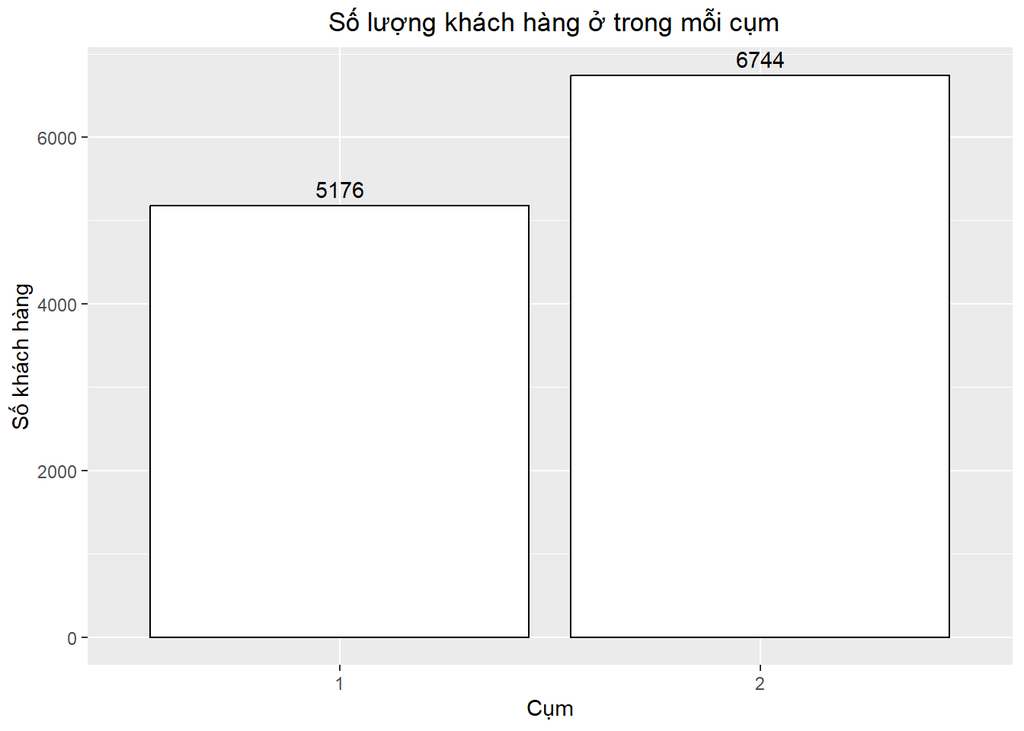

```r
library(ggplot2)
ggplot(airline_data, aes(x=Cluster))+
  geom_bar(fill="white",color="black")+
  geom_text(stat = "count", aes(label = ..count..), vjust = -0.5) +
  labs(x="Cụm",
      y="Số khách hàng",
      title=" Số lượng khách hàng ở trong mỗi cụm") +
  theme(
    plot.title = element_text(hjust = 0.5)
  )
```

## Common Customer Types in Each Cluster

The proportion of returning customers (i.e., those who have used US airline’s services more than twice) is calculated as follows:

- Cluster 1: 78.6%
- Cluster 2: 87.8%

Thus, cluster 2 has a higher loyalty rate, and this group feels quite satisfied with the Comfort and Convenience of flying. This could be one of the main factors attracting customers to return and use the airline’s services again.

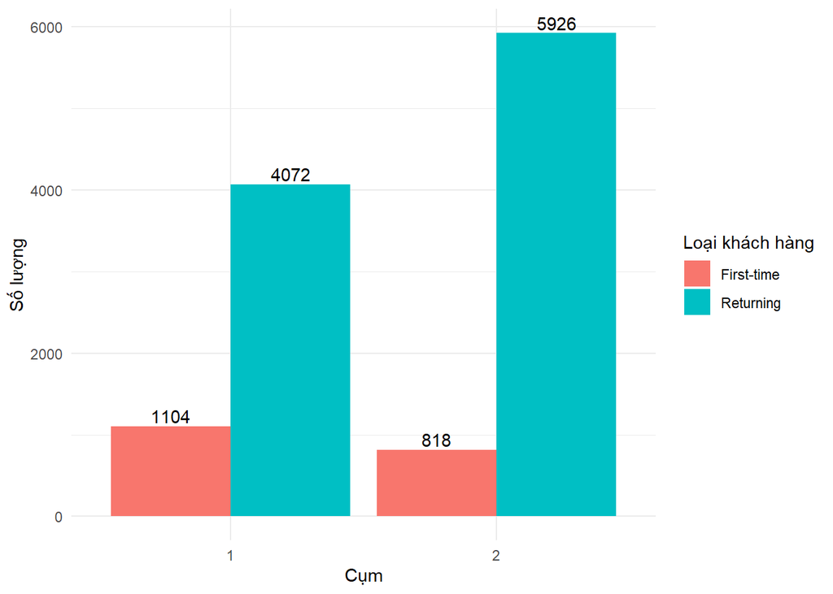

```r
library(ggplot2)

ggplot(airline_data, aes(x =Cluster, fill = `Customer Type`)) +
    geom_bar(position = "dodge") + #các cột đặt cạnh nhau
    geom_text(
        stat = "count",
        aes(label = ..count..),
        position = position_dodge(width = 0.9), #Đảm bảo số nằm trên đúng cột tương ứng
        vjust = -0.25 #Đặt nhãn lên phía trên đầu cột
    ) +
    labs(
        x = "Cụm",
        y = "Số lượng",
        fill = "Loại khách hàng"
    ) +
    theme_minimal()
```

## Average Age of Two Clusters

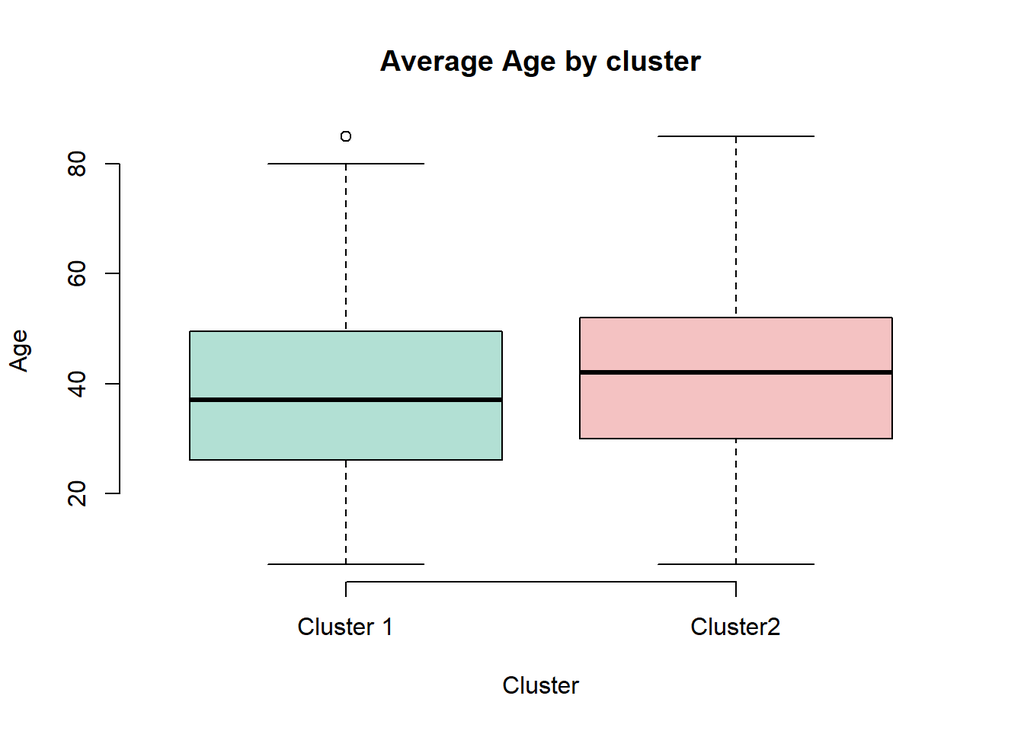

```r
boxplot(Age ~ Cluster, data = airline_data, main = "Average Age by cluster", frame = FALSE, names=c("Cluster 1", "Cluster2"), col=c("#B2E0D4","#F4C2C2"))
```

## Age Groups in Each Cluster

First of all, the author based the age group classification of customers on information from the U.S. Census Bureau. Link: (https://www.beresfordresearch.com/age-range-by-generation/)

Bảng nhóm thế hệ và độ tuổi tương ứng (năm 2015)

| Thế hệ | Năm sinh | Độ tuổi năm 2015 |
| --- | --- | --- |
| Silent | <=1945 | >=70 |
| Baby Boomer | 1946–1964 | 51–69 |
| Gen X | 1965–1980 | 35–50 |
| Millennial | 1981–1996 | 19–34 |
| Gen Z | 1997–2008 | 7–18 |

After that, two pie charts was created to display the proportion of every generation label in each customer clustering group.

```r
# Tao bien
airline_data <- airline_data %>%
  mutate(age_group = case_when(
    Age >= 7 & Age <= 18 ~ "GenZ",
    Age > 18 & Age <= 34 ~ "Millenials",
    Age > 34 & Age <= 50 ~ "GenX",
    Age > 50 & Age <= 69 ~ "Baby Boomer",
    Age > 69 ~ "Silent",
     TRUE ~ NA_character_ ),
    .before = 4)

#Sap xep thu tu
airline_data$age_group <- factor(airline_data$age_group,
                                 levels = c("GenZ", "Millenials", "GenX", "Baby Boomer", "Silent"))

# kiem tra co Na khong
sum(is.na(airline_data$age_group))
```

```
## [1] 0
```

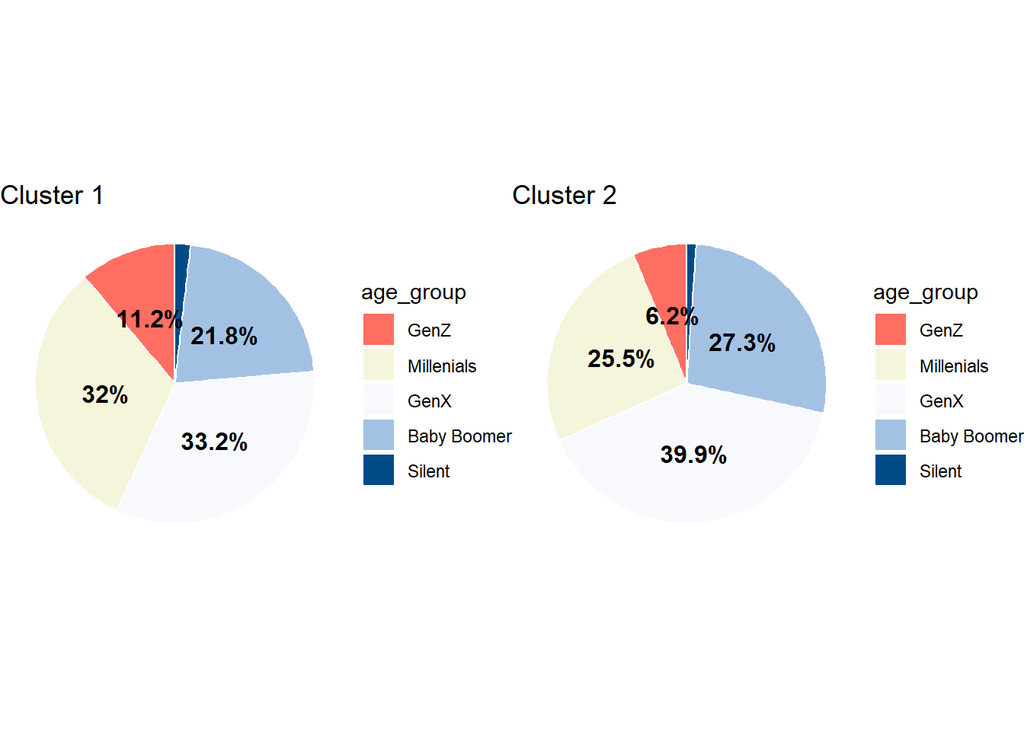

```r
library(ggplot2)
library(dplyr)
library(gridExtra)

# Tính toán dữ liệu
age_cluster_summary <- airline_data %>%
  group_by(Cluster, age_group) %>%
  summarise(count = n(), .groups = "drop") %>%
  group_by(Cluster) %>%
  mutate(
    percentage = count / sum(count) * 100,
    label = ifelse(percentage < 5, "", paste0(round(percentage, 1), "%")) #Để lúc sau hiện trên pie chart các giá trị nhỏ không bị overlap
  ) %>%
  ungroup()

# Màu sắc theo nhóm tuổi
age_group_colors <- c(
  "GenZ" = "#FF6F61",
  "Millenials" = "#F5F5DC",
  "GenX" = "#F7F9FC",
  "Baby Boomer" = "#A3C2E3",
  "Silent" = "#004B87"
)

# Hàm tạo pie chart
create_pie <- function(data, cluster_num) {
  cluster_data <- data %>% filter(Cluster == cluster_num)

  ggplot(cluster_data, aes(x = "", y = count, fill = age_group)) +
    geom_bar(stat = "identity", width = 1, color = "white") +
    coord_polar(theta = "y") +
    scale_fill_manual(values = age_group_colors) +
    geom_text(
      aes(label = label),
      position = position_stack(vjust = 0.5),
      size = 4.2,
      fontface = "bold",
      color = "black"
    ) +
    labs(title = paste("Cluster", cluster_num), x = NULL, y = NULL) +
    theme_void() +
    theme(legend.position = "right")
}

# Tạo hai biểu đồ
p1 <- create_pie(age_cluster_summary, 1)
p2 <- create_pie(age_cluster_summary, 2)

# Hiển thị song song
grid.arrange(p1, p2, ncol = 2)
```

Moreover, in Cluster 1, there are noticeably more Millennials and Gen Z customers compared to Cluster 2. In other words, Cluster 1 has a younger customer base. This age group places more emphasis on form and aesthetics, but given the characteristics of Cluster 1 (not feeling comfortable with onboard amenities), it suggests that US Airways’ facilities are not yet modern or updated enough to meet the expectations of today’s younger generation. This might be due to using older models or suboptimal layout arrangements.

## Arrival and Departure Delay Times

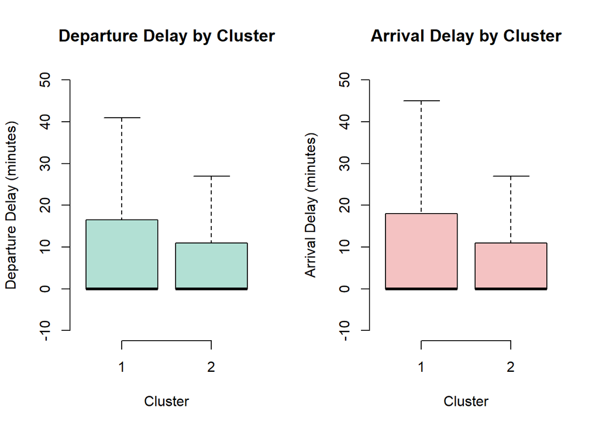

```r
# Đặt song song
par(mfrow = c(1, 2))

# Boxplot Departure Delay
boxplot(`Departure Delay` ~ Cluster, data = airline_data,
        main = "Departure Delay by Cluster",
        xlab = "Cluster",
        ylab = "Departure Delay (minutes)",
        col = "#B2E0D4",
        frame = FALSE,
        outline = FALSE,
        ylim = c(-10, 50))

# Boxplot Arrival Delay
boxplot(`Arrival Delay` ~ Cluster, data = airline_data,
        main = "Arrival Delay by Cluster",
        xlab = "Cluster",
        ylab = "Arrival Delay (minutes)",
        col = "#F4C2C2",
        frame = FALSE,
        outline = FALSE,
        ylim = c(-10, 50))
```

## Overall Satisfaction Scores of Clusters

The dataset includes a overall satisfaction variable, which is an average of 14 questions regarding customer satisfaction levels. This variable consists of two categories: Satisfied and No - Neutral. When analyzed by cluster and ticket class, the results are as follows:

```r
library(grid)
library(vcd)

# Tạo bảng chéo
tbl <- xtabs(~ Cluster + Class + Satisfaction, airline_data)
ftable(tbl)
```

```
##                      Satisfaction Neutral or Dissatisfied Satisfied
## Cluster Class
## 1       Business                                     1349       380
##         Economy                                      2750       224
##         Economy Plus                                  438        35
## 2       Business                                      494      3482
##         Economy                                      1675       704
##         Economy Plus                                  217       172
```

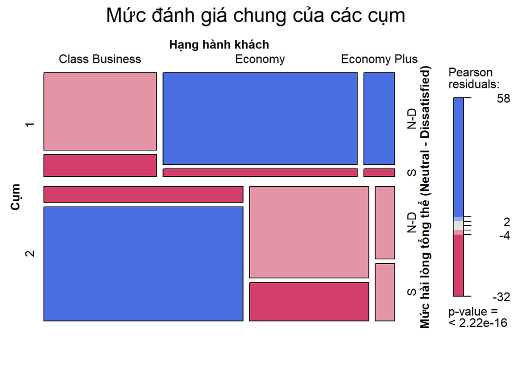

```r
# Vẽ đồ thị mosaic
mosaic(tbl,
       shade = TRUE,
       legend = TRUE,
       labeling_args = list(
         set_varnames = c(Cluster = "Cụm",
                          Class = "Hạng hành khách",
                          Satisfaction = "Mức hài lòng tổng thể (Neutral - Dissatisfied)"),
         set_labels = list(
           Cluster = c("1", "2"),
           Class = c("Class Business", "Economy", "Economy Plus"),
           Satisfaction = c("N-D", "S")
         )
       ),
       main = "Mức đánh giá chung của các cụm"
)
```

In Cluster 1, most customers belong to the Economy class. Additionally, across all three ticket classes, the proportion of customers who are neutral or dissatisfied is higher, especially in the two Economy classes, where satisfaction levels fall below expectations. Given the characteristics of Cluster 1, it can be concluded that in the Economy class, US Airways has yet to provide facilities that meet customers’ needs and the costs they pay. This is an area that US Airways needs to improve for these two ticket classes.

## Cluster Satisfaction Scores on Each Survey Item

In this section, we will compare the satisfaction scores of customers in the two clusters across each category of the airline. The results are as follows:

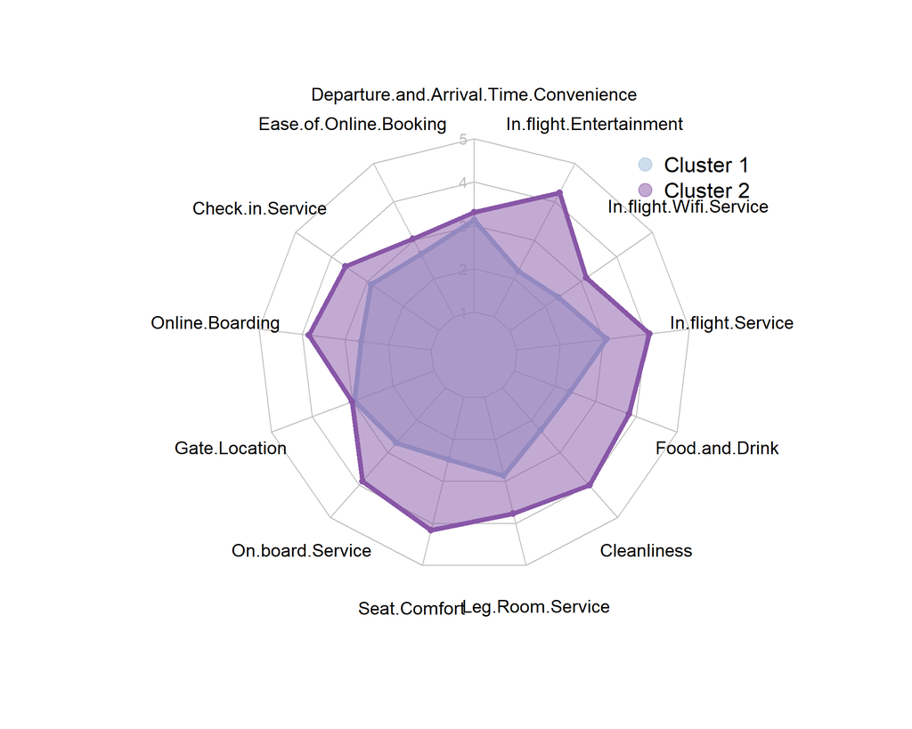

```r
library(fmsb)
library(fmsb)
library(RColorBrewer)
library(scales)

# Chọn cột thang đo (13–23)
survey_cols <- colnames(airline_data)[11:23]

# Trung bình theo cụm
radar_avg <- aggregate(
  x = airline_data[, survey_cols],
  by = list(Cluster = airline_data$Cluster),
  FUN = mean
)

# Chuẩn bị dữ liệu cho radar chart
radar_scores <- radar_avg[, -1]
rownames(radar_scores) <- paste0("Cluster ", radar_avg$Cluster)

# Khai báo max và min của thang đo
radar_data <- rbind(
  rep(5, ncol(radar_scores)),
  rep(1, ncol(radar_scores)),
  radar_scores
)

# Ép kiểu numeric
radar_data <- as.data.frame(lapply(radar_data, as.numeric))
rownames(radar_data) <- c("Max", "Min", rownames(radar_scores))

# Thiết lập màu
coul <- brewer.pal(3, "BuPu")
colors_border <- coul[2:3]        # lấy hai màu
colors_in <- alpha(colors_border, 0.5)

# Vẽ radar chart
radarchart(
  radar_data,
  axistype = 1,
  pcol = colors_border,
  pfcol = colors_in,
  plwd = 5,
  plty = 1,
  cglcol = "grey",
  cglty = 1,
  axislabcol = "grey",
  caxislabels = seq(1, 5, 1),
  cglwd = 1.2,
  vlcex = 1.2
)

#  Thêm chú thích
legend(
  x = 0.7, y = 1,
  legend = rownames(radar_data[-c(1, 2), ]),
  bty = "n",
  pch = 20,
  col = colors_in,
  text.col = "black",
  cex = 1.4,
  pt.cex = 3
)
```

# Conclusion

From the original 14 customer satisfaction measurement variables at US Airways, the study consolidated them into 3 principal components (PCs) using PCA:

PC1 – “Comfort & Boarding Experience”

PC2 – “Logistics & Booking Convenience”

PC3 – “In-flight Service & Amenities”

Next, applying K-means clustering, the author segmented customers into two groups:

Cluster 1: Cabin discomfort (Dissatisfied with comfort and convenience during the flight)

In contrast, Cluster 1 contains younger customers (more Millennials and Gen Z, averaging about 36–37 years old), who mostly choose Economy class and tend to be more lenient in service evaluations. However, they are less satisfied with comfort and amenities on the plane, suggesting that the airline’s facilities and flight experience have not met the expectations of this younger group, who tend to value modernity and aesthetics.

Overall, US Airways performs well in punctuality and maintains a relatively loyal customer base. However, the airline should focus on improving booking services, travel procedures, and enhancing the flight experience, particularly in Economy and Business classes, to better meet the expectations of each target customer segment. Additionally, personalizing and prioritizing experiences according to age groups and ticket classes will be an effective strategy to retain customers and increase satisfaction in the future.